# Problem Set 2

Author

Regan Baros

Published

October 15, 2026

## **GitHub repo:**

https://github.com/rbaros001/EC522_PS2_rbaros

## Data

This data is from the Federal Reserve Economic Data database (FRED). This is an online database consisting of economic time series data. This data set consists of monthly unemployment rate data for the United States and four individual states, California, New York Oregon, and Texas. This data set ranges from 1976-01-01 to 2026-09-01.

```
# A tibble: 6 × 3
  symbol date       price
  <chr>  <date>     <dbl>
1 UNRATE 1976-01-01   7.9
2 UNRATE 1976-02-01   7.7
3 UNRATE 1976-03-01   7.6
4 UNRATE 1976-04-01   7.7
5 UNRATE 1976-05-01   7.4
6 UNRATE 1976-06-01   7.6
```

## Wrangling

**Unemployment Summary**

| region | meanrate | max_rate | min_rate |
| --- | --- | --- | --- |
| California | 7.074342 | 16.1 | 3.8 |
| New York | 6.346546 | 16.7 | 3.8 |
| Oregon | 6.661513 | 13.7 | 3.4 |
| Texas | 5.847040 | 12.8 | 3.4 |
| United States | 6.046305 | 14.8 | 3.4 |

**Unemployment Summary from 2015-01-01 to 2026-09-01**

| region | meanrateR | max_rateR | min_rateR |
| --- | --- | --- | --- |
| California | 5.631429 | 16.1 | 3.8 |
| New York | 5.100714 | 16.7 | 3.8 |
| Oregon | 4.749286 | 13.7 | 3.4 |
| Texas | 4.581429 | 12.8 | 3.4 |
| United States | 4.619858 | 14.8 | 3.4 |

**Unemployment High Extremes Excluding 2020**

| symbol | date | unemployment_rate | region | unemployment_rate_change |
| --- | --- | --- | --- | --- |
| TXUR | 2009-05-01 | 7.6 | Texas | 1.1 |
| ORUR | 2008-12-01 | 8.9 | Oregon | 0.7 |
| ORUR | 2008-11-01 | 8.2 | Oregon | 0.7 |
| ORUR | 2009-01-01 | 9.6 | Oregon | 0.7 |
| ORUR | 1980-03-01 | 7.4 | Oregon | 0.6 |
| UNRATE | 1980-04-01 | 6.9 | United States | 0.6 |

**Unemployment Low Extremes Excluding 2020**

| symbol | date | unemployment_rate | region | unemployment_rate_change |
| --- | --- | --- | --- | --- |
| UNRATE | 1983-07-01 | 9.4 | United States | -0.7 |
| NYUR | 2021-09-01 | 6.2 | New York | -0.6 |
| ORUR | 1977-05-01 | 7.8 | Oregon | -0.5 |
| CAUR | 2021-07-01 | 7.4 | California | -0.5 |
| CAUR | 2021-09-01 | 6.5 | California | -0.5 |
| NYUR | 2021-07-01 | 7.0 | New York | -0.5 |
| UNRATE | 2010-12-01 | 9.3 | United States | -0.5 |
| UNRATE | 2014-04-01 | 6.2 | United States | -0.5 |
| UNRATE | 2021-07-01 | 5.4 | United States | -0.5 |

## Visualization

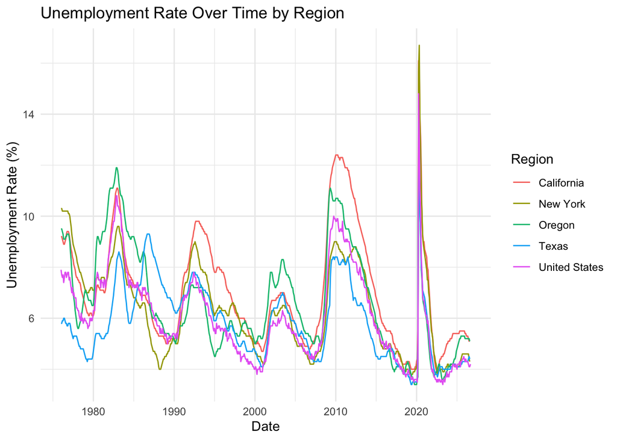

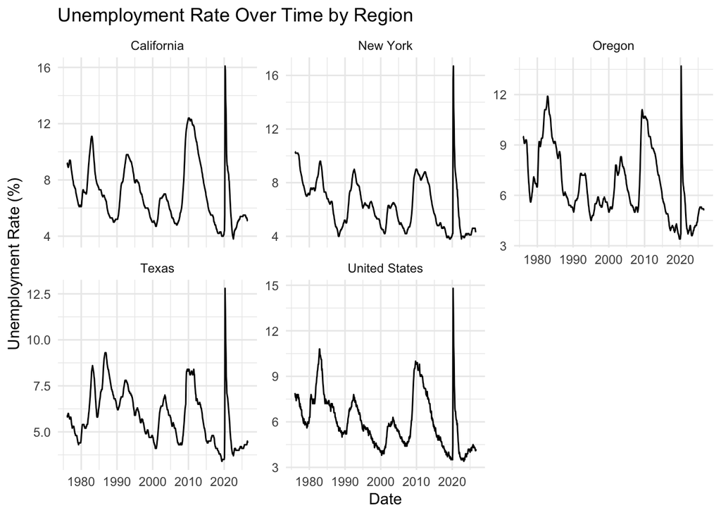

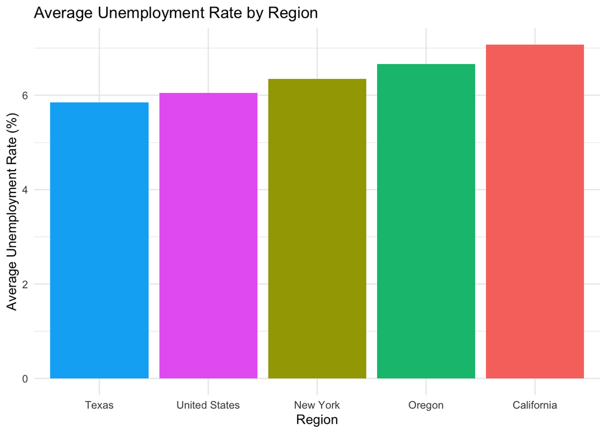

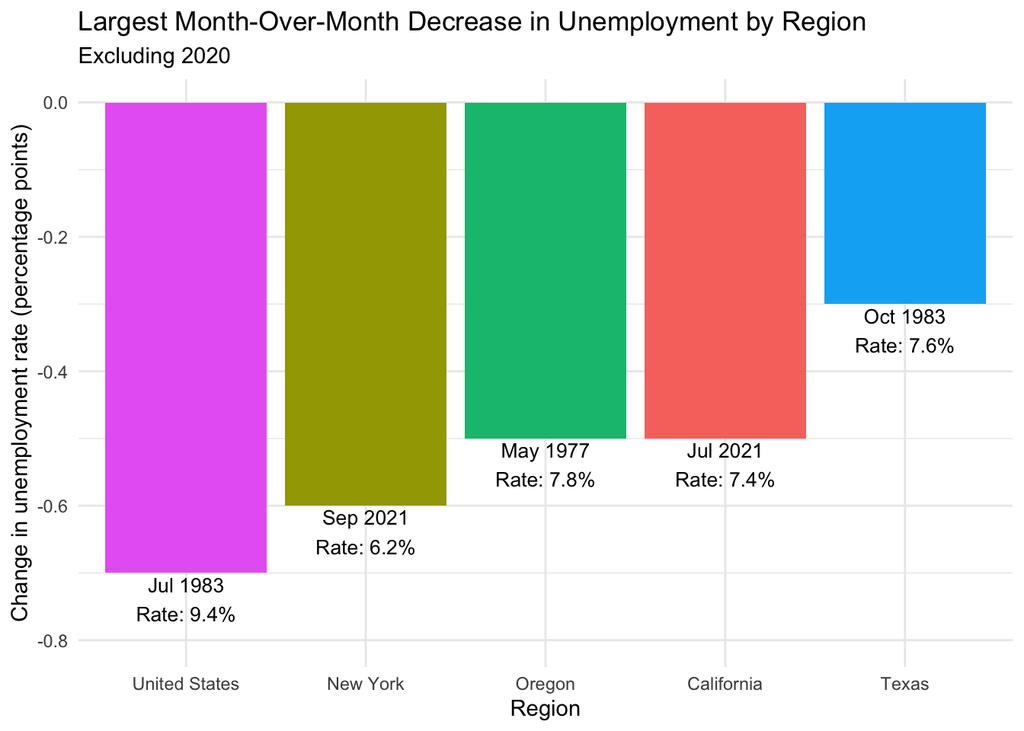

Each bar is the largest month-over-month decrease i the unemployment rate for that region, excluding 2020. The label gives the month and year this occurred as well as the unemployment rate associated with this change. The rate is the unemployment rate after the drop.

## Reflection

Overall, this was a very informative process. I feel as though I have a much better understanding of what each function does and how to use it properly. I learned so much more about R, Git, Github, and Quarto than when I started. Something I was getting tripped up on in the beginning was git commits, but I definitely feel more comfortable with it now. I really enjoyed playing around with different graphs and how it looks when using different variables. I also really enjoy how professional Quarto documents look, I hadn’t used them much before this assignment. Something I look forward to doing next time is continuing building a forecasting framework and understanding more R commands.